# asd_screening

## Autism Spectrum Disorder screening data for toddlers (using Python Pandas & Seaborn)

*dataset from Kaggle: "Autism Spectrum Disorder screening data for toddlers in Saudi Arabia" (downloaded: 29.10.2022)*

```python
import pandas as pd
import seaborn as sns
from matplotlib import pyplot as plt
from scipy.stats import f_oneway
import scipy.stats
from statsmodels.stats.weightstats import ztest as ztest

import warnings
warnings.filterwarnings('ignore')
```

Loading the dataset and dropping unnecessary columns:

```python
df = pd.read_csv('Autism Spectrum Disorder Screening Data for Toddlers in Saudi Arabia Data Set.csv')
df.drop(df.columns[[0, 10, 12]], axis = 1, inplace = True)
```

```python
df.info()
```

```
<class 'pandas.core.frame.DataFrame'>
RangeIndex: 506 entries, 0 to 505
Data columns (total 14 columns):
 #   Column                          Non-Null Count  Dtype
---  ------                          --------------  -----
 0   A9                              506 non-null    int64
 1   A8                              506 non-null    int64
 2   A7                              506 non-null    int64
 3   A6                              506 non-null    int64
 4   A5                              506 non-null    int64
 5   A4                              506 non-null    int64
 6   A3                              506 non-null    int64
 7   A2                              506 non-null    int64
 8   A1                              506 non-null    int64
 9   Family member with ASD history  506 non-null    object
 10  Age                             506 non-null    int64
 11  Gender                          506 non-null    object
 12  Screening Score                 506 non-null    int64
 13  Class                           506 non-null    int64
dtypes: int64(12), object(2)
memory usage: 55.5+ KB
```

Converting 'Age' values from months to years (for easier grouping):

```python
def convertAge(x):
    age = round((x/12)*2)/2.0
    return age

df['Age'] = df['Age'].apply(convertAge)
```

Replacing Yes/No values with binary ones:

```python
df['Family member with ASD history'].replace({'Yes' : 1, 'No' : 0}, inplace = True)
```

```python
df.head(10)
```

|  | A9 | A8 | A7 | A6 | A5 | A4 | A3 | A2 | A1 | Family member with ASD history | Age | Gender | Screening Score | Class |
| --- | --- | --- | --- | --- | --- | --- | --- | --- | --- | --- | --- | --- | --- | --- |
| 0 | 0 | 1 | 1 | 1 | 0 | 0 | 0 | 0 | 0 | 0 | 2.5 | Female | 3 | 0 |
| 1 | 0 | 1 | 0 | 0 | 1 | 0 | 1 | 0 | 0 | 0 | 2.5 | Female | 3 | 0 |
| 2 | 0 | 0 | 1 | 0 | 0 | 0 | 0 | 0 | 0 | 0 | 3.0 | Male | 1 | 0 |
| 3 | 0 | 0 | 0 | 0 | 0 | 0 | 0 | 0 | 0 | 1 | 3.0 | Female | 0 | 0 |
| 4 | 0 | 0 | 0 | 0 | 0 | 0 | 0 | 0 | 0 | 0 | 3.0 | Female | 0 | 0 |
| 5 | 0 | 0 | 1 | 1 | 1 | 0 | 1 | 0 | 0 | 0 | 1.5 | Male | 4 | 1 |
| 6 | 0 | 1 | 1 | 1 | 1 | 0 | 1 | 0 | 1 | 0 | 1.5 | Female | 6 | 1 |
| 7 | 0 | 0 | 0 | 0 | 0 | 0 | 0 | 0 | 0 | 0 | 2.0 | Female | 0 | 0 |
| 8 | 0 | 0 | 0 | 0 | 0 | 0 | 0 | 0 | 0 | 0 | 2.0 | Male | 0 | 0 |
| 9 | 0 | 1 | 0 | 0 | 1 | 0 | 0 | 0 | 0 | 0 | 2.0 | Male | 2 | 0 |

Checking for total number of male and female patients and for their average screening score results:

```python
genderFrame = df['Gender'].value_counts().to_frame()
scoreFrame = df.groupby(['Gender']).mean()['Screening Score'].to_frame()

genderResult = pd.concat([genderFrame, scoreFrame], axis = 1, join = 'inner')
genderResult.rename(columns = {'Gender': 'Count', 'Screening Score' : 'Average Screening Score'}, inplace = True)
genderResult
```

|  | Count | Average Screening Score |
| --- | --- | --- |
| Female | 349 | 5.332378 |
| Male | 157 | 5.840764 |

One-way ANOVA test:

```python
ageList = df['Age'].unique()
ageList.sort()
ageScores = []

for age in ageList:
    ageFltr = (df['Age']) == age
    result = pd.Series(df[ageFltr]['Screening Score'])
    ageScores.append(result)

f_oneway(*ageScores) #oneway anova test
```

```
F_onewayResult(statistic=3.5658890819322995, pvalue=0.007006330549077022)
```

###### ANOVA test results: F-statistic = 3.566 p-value: 0.007 (< 0.05)

Two-sampled Z-TEST:

```python
genderList = df['Gender'].unique()
genderScores = []

for gender in genderList:
    genderFltr = (df['Gender']) == gender
    result = pd.Series(df[genderFltr]['Screening Score'])
    genderScores.append(result)

ztest(*genderScores, value = 0) #two sample z-test
```

```
(-1.6656113371226333, 0.0957908515914982)
```

###### Z-test results: Z-score = -1.666 p-value = 0.0958 (> 0.05)

Checking correlation between family members with ASD history and ASD presence:

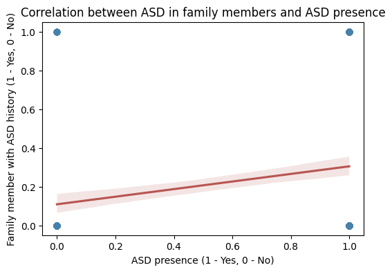

```
PearsonRResult(statistic=0.21468204201670738, pvalue=1.092758157837489e-06)
```

```python
plt.figure(figsize=(6, 4))
sns.regplot(x = df['Class'], y = df['Family member with ASD history'], color = '#4781AA', line_kws = {'color':'#B85652'})
plt.title('Correlation between ASD in family members and ASD presence')
plt.ylabel('Family member with ASD history (1 - Yes, 0 - No)')
plt.xlabel('ASD presence (1 - Yes, 0 - No)')
plt.show()

scipy.stats.pearsonr(x = df['Class'], y = df['Family member with ASD history'])
```

###### Pearson Correlation Coefficient results: r = 0.215 (small positive correlation between two variables) p-value = 1.093e-06 (< 0.05)

Checking correlation between answers for questions from the questionnaire:

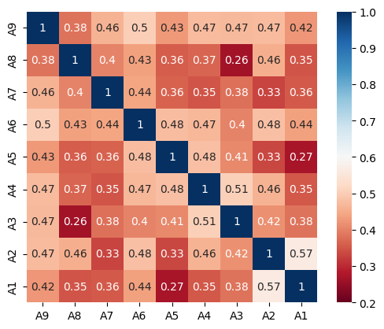

```python
correlation = df.iloc[:,0:9].corr()
sns.heatmap(correlation, cmap = 'RdBu', vmin = 0.2, vmax = 1, annot = True, square = True)
```

###### Biggest correlation is between questions A1 and A2 (0.57). Smallest correlation is between questions A3 and A8 (0.26), A1 and A5 (0.27).

Checking for outliers:

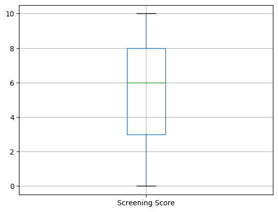

```python
df.boxplot(column = ['Screening Score'])
plt.show()
```

Analyzing screening score results in different age groups:

```python
ssFrame = df.groupby(['Age']).mean()['Screening Score'].to_frame()
ssFrame.rename(columns = {'Screening Score' : 'Average Screening Score'}, inplace = True)
ssFrame
```

| Age | Average Screening Score |
| --- | --- |
| 1.0 | 5.021053 |
| 1.5 | 4.961165 |
| 2.0 | 5.254386 |
| 2.5 | 6.357143 |
| 3.0 | 6.050725 |

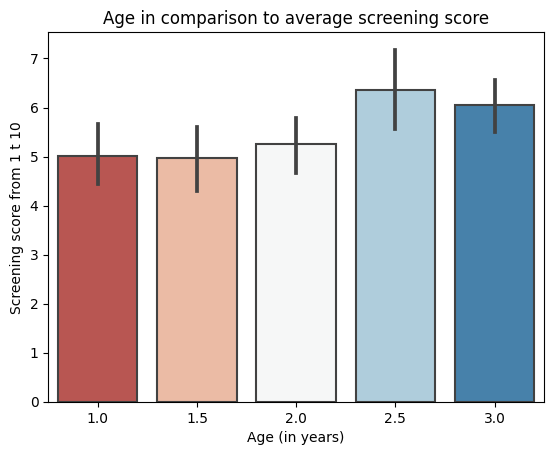

```python
vis = sns.barplot(ageScores, palette = 'RdBu', edgecolor = '#424242', linewidth = 1.5).set_xticks(range(len(ageScores)), labels = ageList)
plt.xlabel('Age (in years)')
plt.ylabel('Screening score from 1 t 10')
plt.title('Age in comparison to average screening score')
```

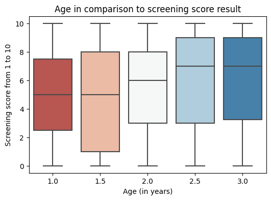

```python
plt.figure(figsize=(6, 4))
sns.boxplot(x = df['Age'], y = df['Screening Score'], palette = 'RdBu')
plt.title('Age in comparison to screening score result')
plt.xlabel('Age (in years)')
plt.ylabel('Screening score from 1 to 10')
plt.show()
```

*ABOUT THE DATASET*  
Based on information about this dataset downloaded from Kaggle, screening questions from A1 to A9 were:  
A1: Does your child look at you when you call his/her name?  
A2: How easy it is for you the get eye contact with your child?  
A3: Does your child point to indicate that he/she wants something? (eg. a toy that is out of reach)  
A4: Does your child point to share interest with you? (eg. pointing at an interesting sight)  
A5: Does your child pretend? (eg. talks on a toy phone)  
A6: Does your child follow where you are looking?  
A7: If you or someone else in the family is visibly upset, does your child show signs of wanting to comfort them?  
A8: Would you describe your child's first word as typical or not?  
A9: Does your child use simple gestures? (eg. wave goodbye)  
Column "Class" shows presence of ASD based on screening score results from questions from A1 to A10 (1 - ASD traits, 0 - no ASD traits)  
I did not include question A10 in my analysis due to reverse scoring, which can lead to inadequate results.  
Exact info about the questions and possible answers is here on Kaggle: https://www.kaggle.com/datasets/asdpredictioninsaudi/asd-screening-data-for-toddlers-in-saudi-arabia  
*Dataset analysis made by Joanna Nowacka (www.asiazow.github.io)*